# If he has the season we expect, what’s he worth next year?

A simulation model of dynasty value

Joe Sydlowski

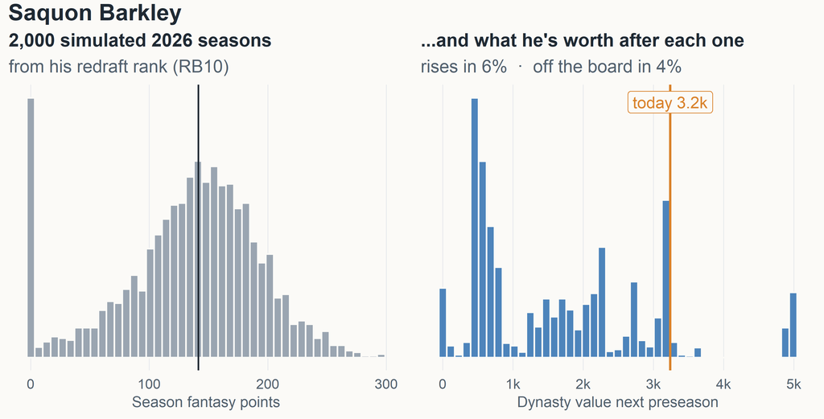

## Two markets, one of them sharp

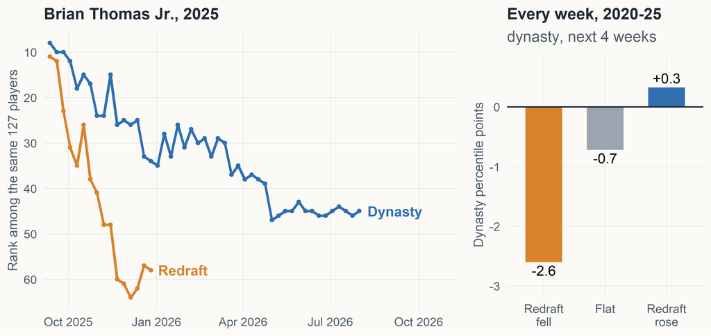

## The question

Take the redraft market as right.

If a player has **the season it expects**, what happens to his **dynasty value**?

ffsimulator (Tan Ho, ffverse) came out of conversations Tan and I had: redraft rankings in, simulated seasons out.  
This project is the next step: from those seasons to next year’s dynasty value.

## How it works

[figure not shown]

## 1. A season is only good relative to what was expected

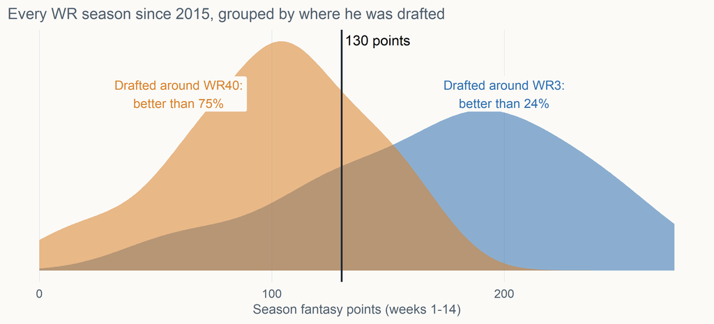

## 2. Borrow from players who looked like him

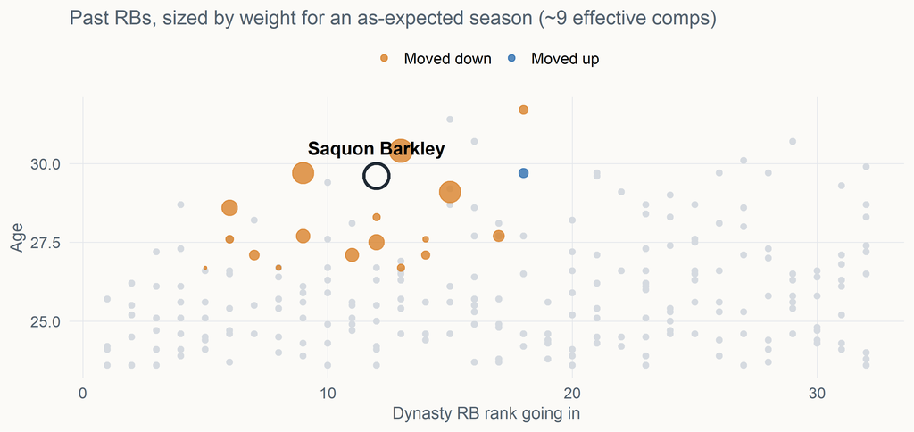

## 3. Falling off the board is an outcome, not missing data

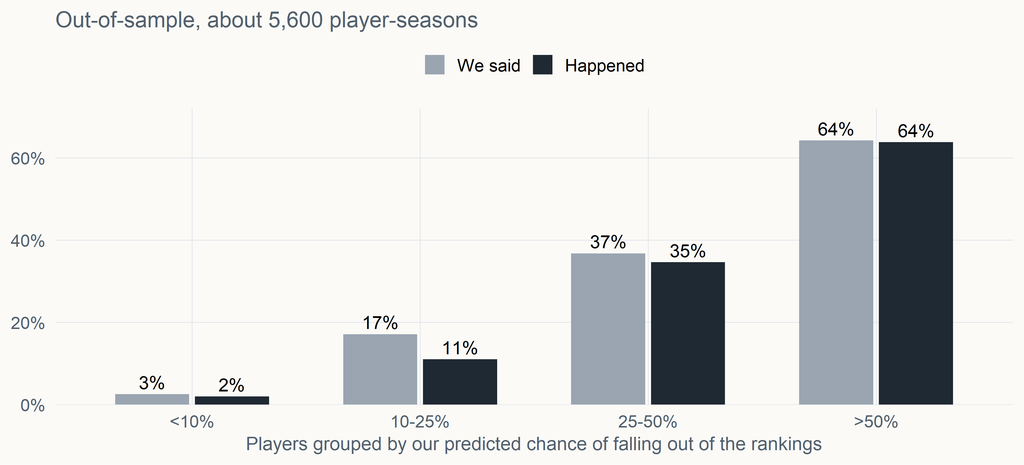

## One price, two assets

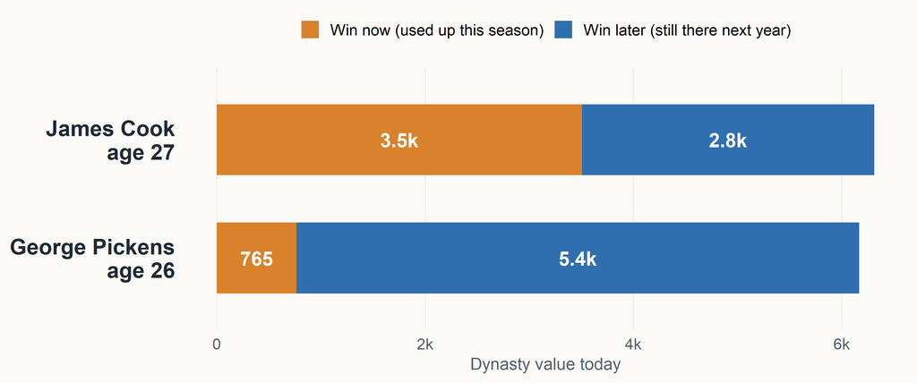

Win later = median value next preseason. Win now = today’s price minus that.

## How I know it works: the 11-holdout backtest

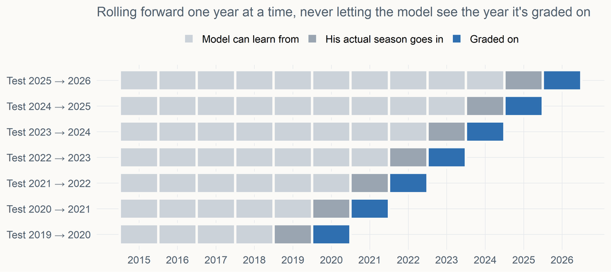

## What “working” means

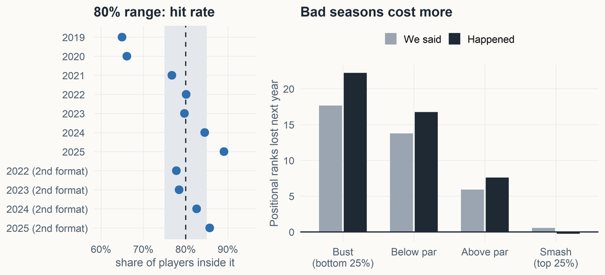

## Why 11 tests and not 1

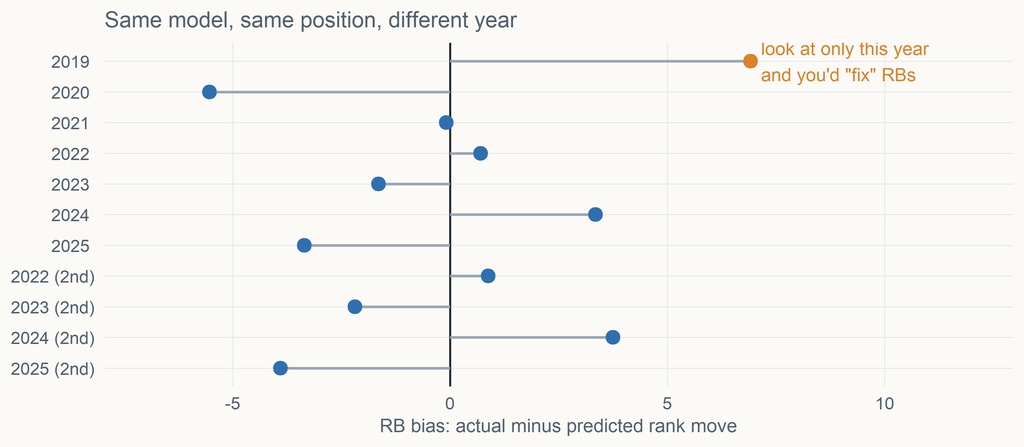

## What didn’t make it

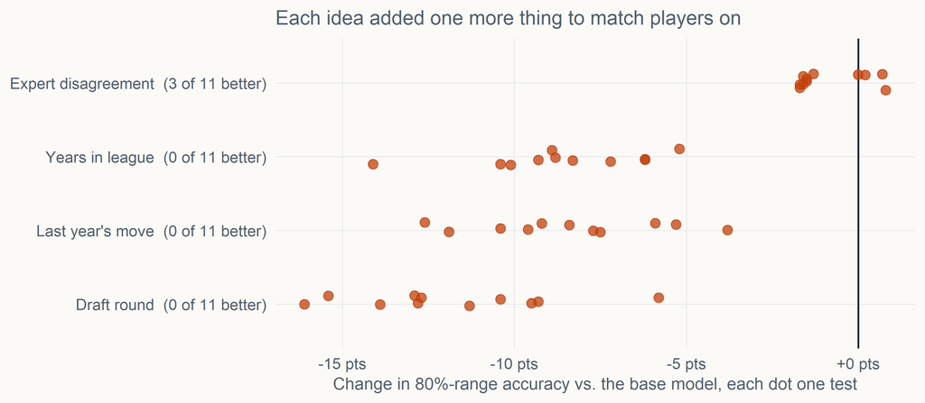

## The hard part: the model was too sure about stars

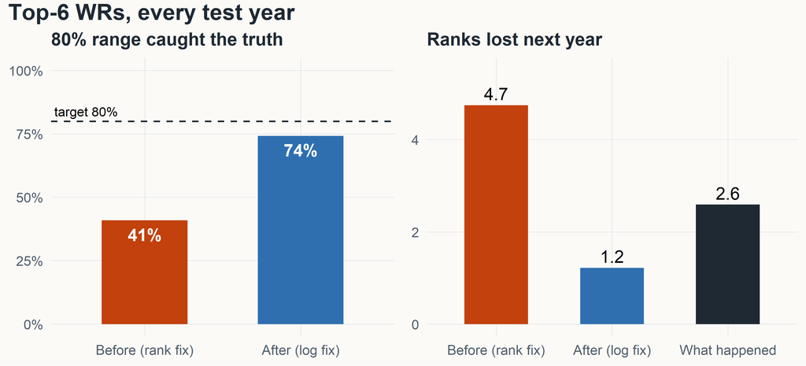

## The fix: think in ratios, not ranks

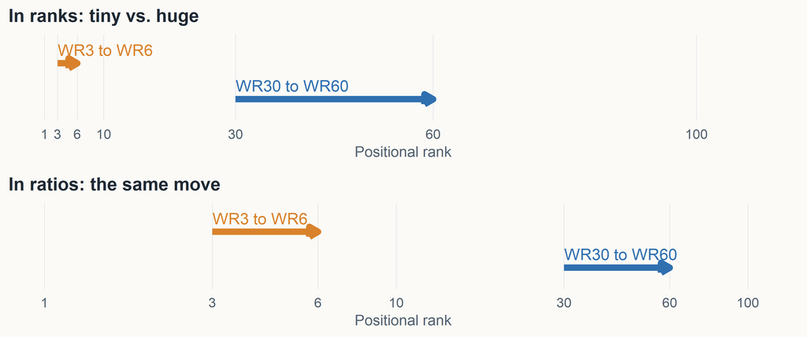

## What that did to the split

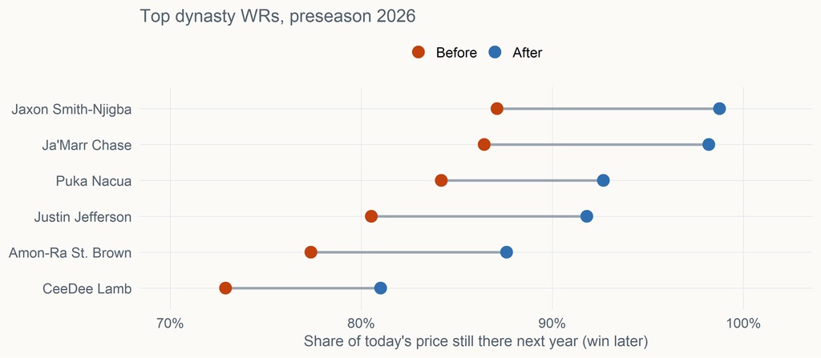

## Small thing, big effect: median, not mean

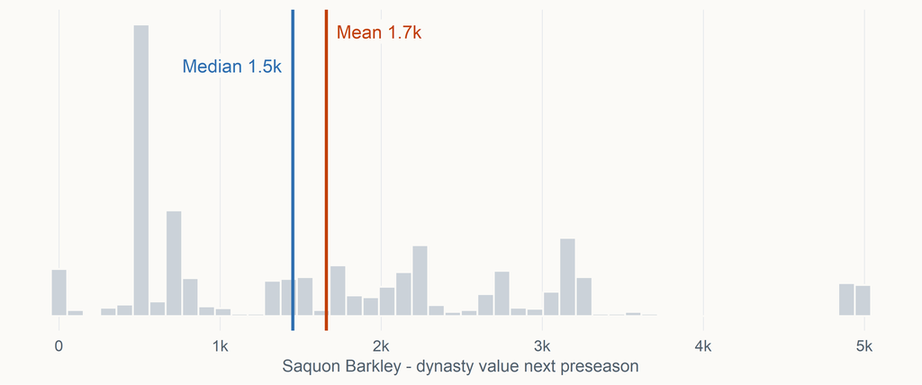

## Live check: this season so far

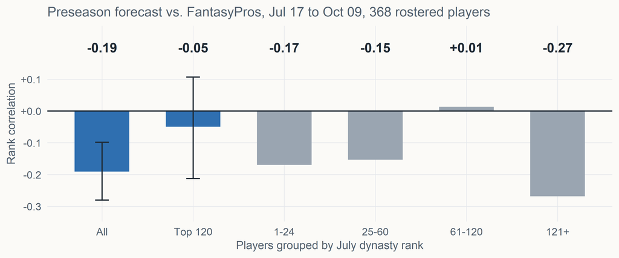

## Same problem in soccer

| Fantasy | Soccer |
| --- | --- |
| Redraft rankings: the sharp line | Match and season markets, xG-based projections |
| Dynasty price | Transfer fee / squad valuation |
| Win now vs. win later | This season’s contribution vs. resale value |
| Falls off the board | Released, loaned out, drops a division |
| Thin positions (TE, QB) | Thin positions (GK) |
| Age curves | Age curves, contract years |

## What I’d do differently

Take the sharp price as right.  
Spend the effort on what it doesn’t tell you.

Questions

# Appendix

## A. The matching weights

| Matched on | How close counts |  |
| --- | --- | --- |
| Position | exact |  |
| Dynasty positional rank | within 8 spots (triangular) |  |
| Age | within 3 years (triangular) |  |
| Season quality Q | within 0.25 (triangular) |  |

Exit chance is shrunk toward a broader rate when the pool is thin (effective sample size, kappa = 10). Moves are drawn in log rank, then lightly shrunk and widened per position (fit across all 11 tests).

## B. Overall accuracy, before vs. after the log fix

| Model | 80% range hit rate | Avg miss (ranks) | Players |
| --- | --- | --- | --- |
| Before (rank fix) | 83% | 9.41 | 1985 |
| After (log fix) | 86% | 9.22 | 1985 |

Players worth at least 150 in value, survivors only, all 11 tests.

## C. Exit calibration

| Predicted bucket | We said | Happened | Players |
| --- | --- | --- | --- |
| <10% | 3% | 2% | 2401 |
| 10-25% | 17% | 11% | 1042 |
| 25-50% | 37% | 35% | 1207 |
| >50% | 64% | 64% | 921 |